# Lab-5.1: Comparing and Contrasting the results from different predicitive methods on Airbnb Data to see if price Listings had any predictability during 2022 within the United States.

**Author**: Karan Uppal

#### Setup

Data Source: http://insideairbnb.com/get-the-data

Data Dictionary:

- Price: Price listing _ neighbourhood: area ZIP codes
- latitude: Uses the World Geodetic System (WGS84) projection for latitude and longitude.
- longitude: Uses the World Geodetic System (WGS84) projection for latitude and longitude.
- room_type: All homes are grouped into the following three room types:

Entire place Private room Shared room

- price: daily price in local currency
- minimum_nights: minimum number of night stay for the listing (calendar rules may be different)
- number_of_reviews: The number of reviews the listing has
- reviews_per_month: The number of reviews the listing has over the lifetime of the listing
- calculated_host_listings_count: The number of Entire home/apt listings the host has in the current scrape, in the city/region geography
- availability_365: The availability of the listing 365 days in the future as determined by the calendar. Note a listing may not be available because it has been booked by a guest or blocked by the host.
- number_of_reviews_ltm: The number of reviews the listing has (in the last 12 months)
- time_since_last_review: Time in minutes since last review was posted
- log_price: Log function of price module

```r
require(ISLR)
require(MASS)
require(glmnet)
require(leaps)
# library
library(flextable)
library(leaps)
library(caret)
library(readr)
library(reticulate)
library(corrplot)
library(ggfortify)
library(tidyverse)
library(zoo)
library(lubridate)
library(reshape2)
library(data.table)
library(klaR)
library(feather)
library(yardstick)
library(splines)
library(ISLR)
library(nnet)
library(glmnet)
library(boot)
library('sparkline')
if (!require("pacman")) install.packages("pacman")
pacman::p_load("weights", "interactions", "cjoint", "plm", "interactions", "jtools", "stats", "miceadds", "broom", "RColorBrewer", "ggstatsplot", "ggpubr", "stargazer", "sandwich", "hrbrthemes", "rms", "interplot", "coefplot", "gmodels", "car", "lattice","foreign", "ggplot2", "MASS", "Hmisc", "reshape2", "oddsratio", "tidyr", "psych", "dplyr", "tidyverse", "cjoint", "ISLR","ISLR2","kableExtra","ggExtra","gridExtra")

knitr::opts_chunk$set(tidy.opts=list(width.cutoff=60),tidy=TRUE,echo = TRUE)

def.chunk.hook  <- knitr::knit_hooks$get("chunk")
knitr::knit_hooks$set(chunk = function(x, options) {
  x <- def.chunk.hook(x, options)
  ifelse(options$size != "normalsize", paste0("\n \\", options$size,"\n\n", x, "\n\n \\normalsize"), x)
})
```

Search for all files in the input folder, import and combine

```r
set.seed(1)
alpha <- read.csv("clean_airbnb.csv")

# Drop columns with text data
drop <- c("X", "id", "name", "host_id", "host_name", "neighbourhood_group",
    "last_review", "license")
alpha$neighbourhood <- as.integer(alpha$neighbourhood)
alpha = alpha[, !(names(alpha) %in% drop)]
head(alpha)
```

```
  neighbourhood latitude longitude       room_type price minimum_nights
1         78702 30.26057 -97.73441 Entire home/apt   111              2
2         78729 30.45697 -97.78422    Private room    39              1
3         78704 30.24885 -97.73587 Entire home/apt    66             30
4         78704 30.26034 -97.76487 Entire home/apt   149              3
5         78741 30.23466 -97.73682 Entire home/apt    44              3
6         78702 30.26543 -97.71338 Entire home/apt   750              4
  number_of_reviews reviews_per_month calculated_host_listings_count
1               601              3.72                              1
2               264              1.78                              1
3               118              0.78                              1
4               278              2.12                              1
5                48              0.32                              1
6               124              0.99                              1
  availability_365 number_of_reviews_ltm       date time_since_last_review
1              309                    44 2022-06-08                     14
2               58                     1 2022-06-08                    340
3                0                     2 2022-06-08                      8
4               90                    33 2022-06-08                     17
5               83                     2 2022-06-08                    207
6                0                     0 2022-06-08                   1179
  log_price long_stay old_listing
1  4.709530         0           0
2  3.663562         0           0
3  4.189655         1           0
4  5.003946         0           0
5  3.784190         0           0
6  6.620073         0           1
```

Split the data set into a training set and a test set.

```r
trainIndex <- createDataPartition(alpha$log_price, p = 0.7, list = FALSE)
alpha_train <- alpha[trainIndex, ]
alpha_test <- alpha[-trainIndex, ]

# Print the dimensions of the training and testing sets
cat("Training set dimensions:", dim(alpha_train), "\n")
```

```
Training set dimensions: 34603 16
```

```r
cat("Testing set dimensions:", dim(alpha_test), "\n")
```

```
Testing set dimensions: 14828 16
```

```r
# control <- trainControl(method='', number=, repeats = ,
# verbose = TRUE, search = 'grid')
```

## Prediction and Model Evaluation

RMSE or Root Mean Squared Error is the default metrics used to evaluate algorithms on regression datasets in caret. RMSE or Root Mean Squared Error is the average deviation of the predictions from the observations.

```r
# Cross validation and control parameters metric = 'RMSE'
# tuneLength = 6

linearModelReg <- lm(log_price ~ room_type + reviews_per_month +
    long_stay + old_listing + date + neighbourhood + minimum_nights +
    number_of_reviews + reviews_per_month + calculated_host_listings_count +
    availability_365 + number_of_reviews_ltm + time_since_last_review,
    data = alpha_train)

LMsum <- summary(linearModelReg)
LMsum
```

```
Call:
lm(formula = log_price ~ room_type + reviews_per_month + long_stay +
    old_listing + date + neighbourhood + minimum_nights + number_of_reviews +
    reviews_per_month + calculated_host_listings_count + availability_365 +
    number_of_reviews_ltm + time_since_last_review, data = alpha_train)

Residuals:
    Min      1Q  Median      3Q     Max
-2.2622 -0.4341 -0.0638  0.3684  3.2577

Coefficients:
                                 Estimate Std. Error  t value Pr(>|t|)
(Intercept)                     3.143e+01  3.597e+00    8.737  < 2e-16 ***
room_typeHotel room            -1.124e-01  8.611e-02   -1.306 0.191608
room_typePrivate room          -9.957e-01  9.748e-03 -102.141  < 2e-16 ***
room_typeShared room           -1.283e+00  5.919e-02  -21.674  < 2e-16 ***
reviews_per_month              -1.020e-01  3.463e-03  -29.461  < 2e-16 ***
long_stay                      -5.070e-01  1.362e-02  -37.233  < 2e-16 ***
old_listing                    -9.351e-02  1.757e-02   -5.321 1.04e-07 ***
date2022-09-12                 -3.599e-02  9.156e-03   -3.931 8.48e-05 ***
date2022-12-15                 -1.405e-01  1.000e-02  -14.043  < 2e-16 ***
date2023-03-16                  4.111e-02  9.909e-03    4.149 3.34e-05 ***
neighbourhood                  -3.299e-04  4.570e-05   -7.218 5.38e-13 ***
minimum_nights                  6.107e-04  1.797e-04    3.399 0.000677 ***
number_of_reviews              -2.256e-04  5.925e-05   -3.808 0.000140 ***
calculated_host_listings_count -1.103e-03  1.063e-04  -10.372  < 2e-16 ***
availability_365                6.119e-04  2.941e-05   20.809  < 2e-16 ***
number_of_reviews_ltm           1.237e-03  3.505e-04    3.530 0.000417 ***
time_since_last_review         -6.004e-06  1.150e-05   -0.522 0.601737
---
Signif. codes:  0 '***' 0.001 '**' 0.01 '*' 0.05 '.' 0.1 ' ' 1

Residual standard error: 0.6368 on 34586 degrees of freedom
Multiple R-squared:  0.2999,    Adjusted R-squared:  0.2995
F-statistic: 925.8 on 16 and 34586 DF,  p-value: < 2.2e-16
```

## Print the lm model and plot the diagnostic plots

```r
linearplotmodel = lm(log_price ~ neighbourhood + number_of_reviews +
    reviews_per_month + availability_365 + number_of_reviews_ltm +
    time_since_last_review, data = alpha_train)

stargazer::stargazer(linearplotmodel, type = "html", summary = TRUE,
    report = "vc*stp", ci = TRUE)
```

|  | *Dependent variable:* |
| --- | --- |
|  | log_price |
| neighbourhood | -0.001*** |
|  | (-0.001, -0.0005) |
|  | t = -10.909 |
|  | p = 0.000 |
| number_of_reviews | -0.0003*** |
|  | (-0.0005, -0.0002) |
|  | t = -4.840 |
|  | p = 0.00001 |
| reviews_per_month | -0.074*** |
|  | (-0.082, -0.066) |
|  | t = -18.344 |
|  | p = 0.000 |
| availability_365 | 0.001*** |
|  | (0.001, 0.001) |
|  | t = 19.554 |
|  | p = 0.000 |
| number_of_reviews_ltm | 0.003*** |
|  | (0.002, 0.004) |
|  | t = 6.818 |
|  | p = 0.000 |
| time_since_last_review | -0.0001*** |
|  | (-0.0001, -0.0001) |
|  | t = -13.485 |
|  | p = 0.000 |
| Constant | 50.243*** |
|  | (42.142, 58.345) |
|  | t = 12.155 |
|  | p = 0.000 |
| Observations | 34,603 |
| R<sup>2</sup> | 0.039 |
| Adjusted R<sup>2</sup> | 0.039 |
| Residual Std. Error | 0.746 (df = 34596) |
| F Statistic | 235.272*** (df = 6; 34596) |
| *Note:* | *p<0.1; **p<0.05;*** p<0.01 |

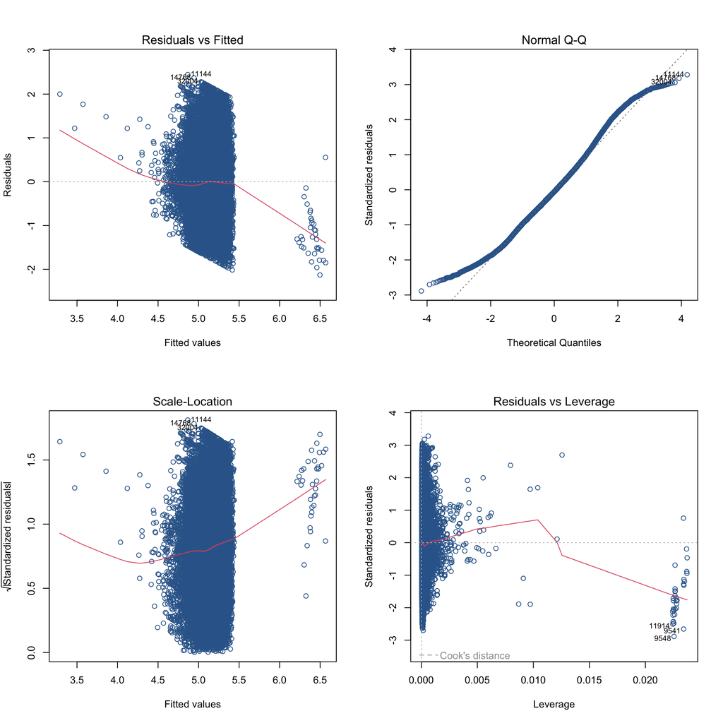

```r
# plotting
par(mfrow = c(2, 2))
plot(linearplotmodel, col = "#336699", pch = 21)
```

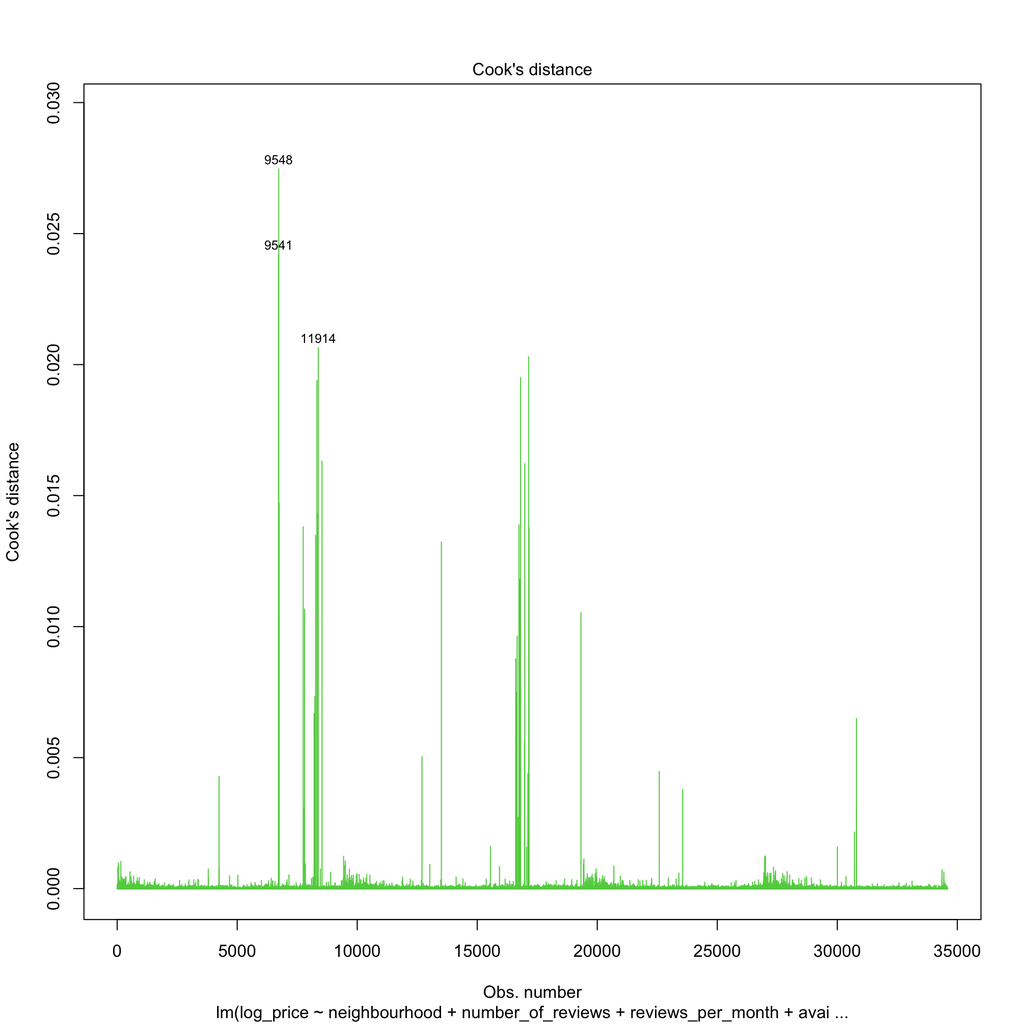

```r
par(mfrow = c(1, 1))
plot(linearplotmodel, 4, col = "336699", pch = 21)
```

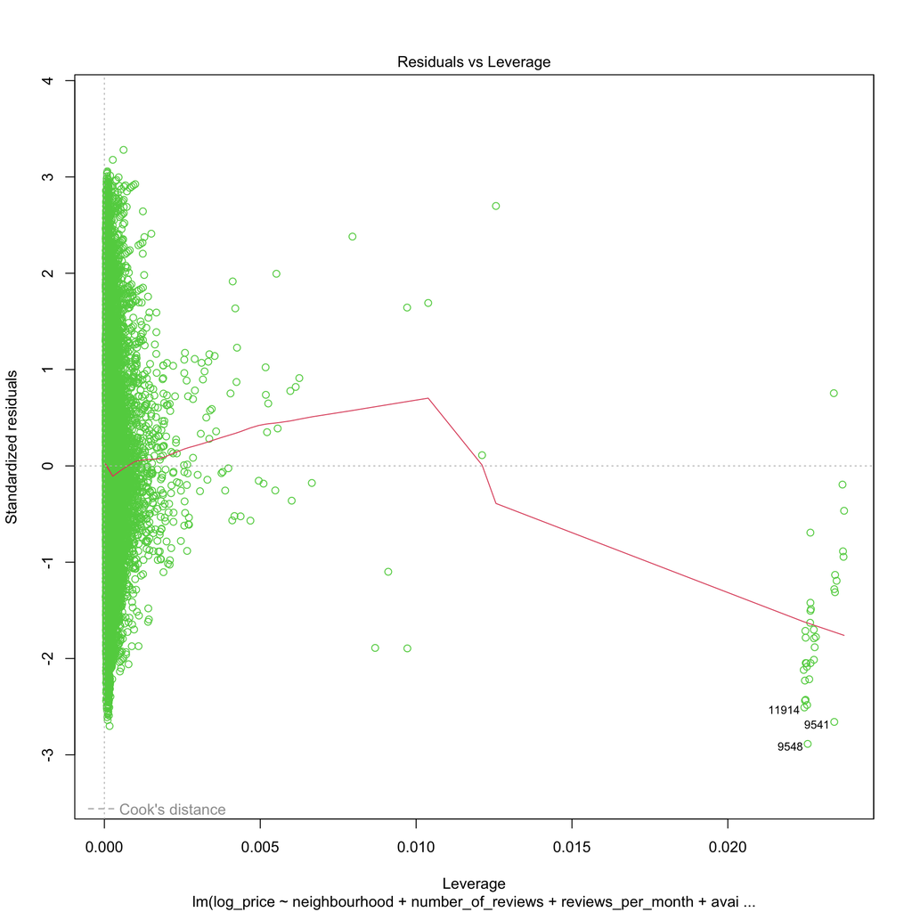

```r
plot(linearplotmodel, 5, col = "336699", pch = 21)
```

## Linear Regression Prediction & Accuracy.

```r
predictions <- predict(linearModelReg, newdata = alpha_test)

rmse <- RMSE(predictions, alpha_test$log_price)

error.rate.linear <- rmse/mean(alpha_test$log_price)

linearr2 <- R2(predictions, alpha_test$log_price)

lineardf <- data.frame(Algorithm = "Linear Regression", RMSE = rmse,
    R2 = linearr2, Error = error.rate.linear)

kable(lineardf) %>%
    kable_styling(bootstrap_options = "striped", full_width = F,
        position = "center")
```

| Algorithm | RMSE | R2 | Error |
| --- | --- | --- | --- |
| Linear Regression | 0.6327496 | 0.3070947 | 0.1234291 |

When looking at the R^2, we can note that it’s significantly less than the RMSE indicating that there’s a smaller possibility of over-fitting.

# Polynominal Regression

Fit the squared polynomial

```r
# ONLY NUMERIC VARIABLES
poly_reg <- lm(log_price ~ poly(neighbourhood, 2) + poly(number_of_reviews,
    2) + poly(reviews_per_month, 2) + poly(availability_365,
    2) + poly(number_of_reviews_ltm, 2) + poly(time_since_last_review,
    2) + poly(calculated_host_listings_count, 2), data = alpha_train)
stargazer::stargazer(poly_reg, type = "html", summary = TRUE,
    report = "vc*stp", ci = TRUE)
```

|  | *Dependent variable:* |
| --- | --- |
|  | log_price |
| poly(neighbourhood, 2)1 | -8.153*** |
|  | (-9.607, -6.699) |
|  | t = -10.991 |
|  | p = 0.000 |
| poly(neighbourhood, 2)2 | -15.334*** |
|  | (-16.801, -13.868) |
|  | t = -20.490 |
|  | p = 0.000 |
| poly(number_of_reviews, 2)1 | -3.432*** |
|  | (-5.457, -1.407) |
|  | t = -3.322 |
|  | p = 0.001 |
| poly(number_of_reviews, 2)2 | -0.193 |
|  | (-1.765, 1.379) |
|  | t = -0.241 |
|  | p = 0.810 |
| poly(reviews_per_month, 2)1 | -25.763*** |
|  | (-28.359, -23.168) |
|  | t = -19.456 |
|  | p = 0.000 |
| poly(reviews_per_month, 2)2 | 9.833*** |
|  | (7.568, 12.098) |
|  | t = 8.509 |
|  | p = 0.000 |
| poly(availability_365, 2)1 | 13.793*** |
|  | (12.067, 15.520) |
|  | t = 15.661 |
|  | p = 0.000 |
| poly(availability_365, 2)2 | -9.079*** |
|  | (-10.700, -7.457) |
|  | t = -10.976 |
|  | p = 0.000 |
| poly(number_of_reviews_ltm, 2)1 | 5.397*** |
|  | (2.414, 8.380) |
|  | t = 3.546 |
|  | p = 0.0004 |
| poly(number_of_reviews_ltm, 2)2 | -4.814*** |
|  | (-7.096, -2.532) |
|  | t = -4.135 |
|  | p = 0.00004 |
| poly(time_since_last_review, 2)1 | -11.194*** |
|  | (-13.119, -9.269) |
|  | t = -11.397 |
|  | p = 0.000 |
| poly(time_since_last_review, 2)2 | 10.301*** |
|  | (8.733, 11.869) |
|  | t = 12.877 |
|  | p = 0.000 |
| poly(calculated_host_listings_count, 2)1 | 0.811 |
|  | (-0.712, 2.334) |
|  | t = 1.044 |
|  | p = 0.297 |
| poly(calculated_host_listings_count, 2)2 | 2.639*** |
|  | (1.171, 4.108) |
|  | t = 3.522 |
|  | p = 0.0005 |
| Constant | 5.130*** |
|  | (5.123, 5.138) |
|  | t = 1,295.022 |
|  | p = 0.000 |
| Observations | 34,603 |
| R<sup>2</sup> | 0.062 |
| Adjusted R<sup>2</sup> | 0.062 |
| Residual Std. Error | 0.737 (df = 34588) |
| F Statistic | 164.380*** (df = 14; 34588) |
| *Note:* | *p<0.1; **p<0.05;*** p<0.01 |

## Polynomial Regression Prediction & Accuracy

Similar to the output of linear regression, the prediction matrix will be made for the polynomial regression.

```r
predictionpoly = predict(poly_reg, newdata = alpha_test)

rmsepoly = RMSE(predictions, alpha_test$log_price)

error.rate.poly = rmse/mean(alpha_test$log_price)

polyrsquare = R2(predictionpoly, alpha_test$log_price)


polydf = data.frame(Algorithm = "Polynomial Regression", RMSE = rmsepoly,
    R2 = polyrsquare, Error = error.rate.poly)

kable(polydf) %>%
    kable_styling(bootstrap_options = "striped", full_width = F,
        position = "center")
```

| Algorithm | RMSE | R2 | Error |
| --- | --- | --- | --- |
| Polynomial Regression | 0.6327496 | 0.0607055 | 0.1234291 |